# 🧑‍💼 Employee Attrition Prediction — Exploratory Data Analysis

**Dataset:** IBM HR Analytics Employee Attrition & Performance (Kaggle) **Source:** https://www.kaggle.com/datasets/pavansubhasht/ibm-hr-analytics-attrition-dataset **Target:** `Attrition` — Did the employee leave the company? (Yes / No) **Domain:** HR Tech / People Analytics **Author:** Narendra Kalam

## 🏦 Business Problem

Large IT services firms such as **TCS, Accenture, and Infosys** invest heavily in training and onboarding — replacing one trained employee typically costs the company **₹5–15 Lakh** (recruiting, ramp-up time, lost productivity, and knowledge drain). Attrition also disrupts client delivery and team morale.

**Goal:** Build a classification model that flags employees who are at high risk of leaving **before** they resign, so HR and people-managers can intervene early with targeted retention actions — compensation review, role change, manager reassignment, or workload rebalancing.

**Success metric for the business:** Recall on the "Yes" (will leave) class matters more than raw accuracy — missing a flight-risk employee is far more costly than a false alarm, since a false alarm only costs a retention conversation.

## 📌 Notebook Workflow

| Step | Topic |
| --- | --- |
| 1 | Import libraries |
| 2 | Data loading and initial inspection |
| 3 | Dataset structure and data types |
| 4 | Missing values analysis |
| 5 | Duplicate detection and cleaning |
| 6 | Constant / redundant column removal |
| 7 | Statistical summary heatmap |
| 8 | Class imbalance analysis (target) |
| 9 | Continuous feature distributions |
| 10 | Categorical feature analysis |
| 11 | Bivariate analysis — continuous features vs Attrition |
| 12 | OverTime vs Attrition — strongest categorical driver |
| 13 | Satisfaction & work-life balance vs Attrition |
| 14 | Outlier detection by Attrition status |
| 15 | Skewness analysis and power transformation |
| 16 | Statistical significance testing (Mann-Whitney U + Cohen's d) |
| 17 | Chi-square test — categorical features vs Attrition |
| 18 | Feature correlation matrix |
| 19 | Income vs Age segmented by Attrition and Job Level |
| 20 | Attrition rate by Department and Job Role (interaction heatmap) |
| 21 | Tenure and career-stagnation analysis |
| 22 | Engineered features preview |
| 23 | Multicollinearity check (VIF) |
| 24 | Class imbalance handling preview (SMOTENC) |
| 25 | Key EDA insights and pipeline design summary |

## Step 1 — Import Libraries

**Why:** All required libraries are imported upfront with a fixed plotting style, so every chart in the notebook is visually consistent. `scipy.stats` powers the Mann-Whitney U and chi-square significance tests used later to confirm that visual patterns are statistically real and not noise. `statsmodels` provides VIF for the multicollinearity check. `imblearn` provides SMOTENC for the class-imbalance preview, since the dataset mixes continuous and categorical/ordinal features.

**Business insight:** Standardizing tooling and style up front is a senior-level habit — it keeps every downstream chart reproducible and avoids ad-hoc styling decisions buried inside individual plot cells.

```python
import warnings
warnings.filterwarnings("ignore")

import numpy as np
import pandas as pd
import matplotlib.pyplot as plt
import matplotlib.ticker as mticker
import seaborn as sns

from scipy import stats
from scipy.stats import mannwhitneyu, chi2_contingency
from sklearn.preprocessing import StandardScaler, PowerTransformer, MinMaxScaler
from sklearn.model_selection import train_test_split
from statsmodels.stats.outliers_influence import variance_inflation_factor
from imblearn.over_sampling import SMOTENC

# Plot style
plt.rcParams.update({
    'figure.facecolor': 'white', 'axes.facecolor': 'white',
    'axes.spines.top': False, 'axes.spines.right': False,
    'font.size': 11, 'axes.titlesize': 13, 'axes.titleweight': 'bold',
    'axes.grid': True, 'grid.alpha': 0.25,
})
BLUE, PINK, GRAY, GREEN, ORANGE = '#2196F3', '#E91E63', '#90A4AE', '#4CAF50', '#FF9800'
PALETTE = [BLUE, PINK]

import sklearn, scipy, statsmodels, imblearn
print(f"pandas       : {pd.__version__}")
print(f"numpy        : {np.__version__}")
print(f"scikit-learn : {sklearn.__version__}")
print(f"scipy        : {scipy.__version__}")
print(f"statsmodels  : {statsmodels.__version__}")
print(f"imbalanced-learn : {imblearn.__version__}")
print("✅ Libraries loaded successfully")
```

```
pandas       : 2.2.3
numpy        : 1.26.4
scikit-learn : 1.3.2
scipy        : 1.11.4
statsmodels  : 0.13.2
imbalanced-learn : 0.12.4
✅ Libraries loaded successfully
```

## Step 2 — Data Loading and Initial Inspection

**Why:** The first look at raw data — shape, column names, and a transposed `head()` — is essential before any cleaning decision. Transposing `head()` makes sense here because the dataset has 35 columns, which would otherwise wrap awkwardly.

**Business context:** The dataset contains 1,470+ current and former employees of a fictional IT/consulting company, with demographic, compensation, satisfaction-survey, and tenure fields. `Attrition` (Yes/No) is the target — whether the employee left the company.

```python
# Update DATA_PATH to point at your local copy of the Kaggle CSV
# (WA_Fn-UseC_-HR-Employee-Attrition.csv)
DATA_PATH = r"D:\Data Science Datasets\Employee Attrition Prediction\WA_Fn-UseC_-HR-Employee-Attrition.csv"

df = pd.read_csv(DATA_PATH)

print(f"Dataset loaded successfully")
print(f"Shape : {df.shape[0]:,} rows x {df.shape[1]} columns")
print()
print("First 3 rows (transposed for readability):")
df.head(3).T
```

```
Dataset loaded successfully
Shape : 1,470 rows x 35 columns

First 3 rows (transposed for readability):
```

|  | 0 | 1 | 2 |
| --- | --- | --- | --- |
| Age | 41 | 49 | 37 |
| Attrition | Yes | No | Yes |
| BusinessTravel | Travel_Rarely | Travel_Frequently | Travel_Rarely |
| DailyRate | 1102 | 279 | 1373 |
| Department | Sales | Research & Development | Research & Development |
| DistanceFromHome | 1 | 8 | 2 |
| Education | 2 | 1 | 2 |
| EducationField | Life Sciences | Life Sciences | Other |
| EmployeeCount | 1 | 1 | 1 |
| EmployeeNumber | 1 | 2 | 4 |
| EnvironmentSatisfaction | 2 | 3 | 4 |
| Gender | Female | Male | Male |
| HourlyRate | 94 | 61 | 92 |
| JobInvolvement | 3 | 2 | 2 |
| JobLevel | 2 | 2 | 1 |
| JobRole | Sales Executive | Research Scientist | Laboratory Technician |
| JobSatisfaction | 4 | 2 | 3 |
| MaritalStatus | Single | Married | Single |
| MonthlyIncome | 5993 | 5130 | 2090 |
| MonthlyRate | 19479 | 24907 | 2396 |
| NumCompaniesWorked | 8 | 1 | 6 |
| Over18 | Y | Y | Y |
| OverTime | Yes | No | Yes |
| PercentSalaryHike | 11 | 23 | 15 |
| PerformanceRating | 3 | 4 | 3 |
| RelationshipSatisfaction | 1 | 4 | 2 |
| StandardHours | 80 | 80 | 80 |
| StockOptionLevel | 0 | 1 | 0 |
| TotalWorkingYears | 8 | 10 | 7 |
| TrainingTimesLastYear | 0 | 3 | 3 |
| WorkLifeBalance | 1 | 3 | 3 |
| YearsAtCompany | 6 | 10 | 0 |
| YearsInCurrentRole | 4 | 7 | 0 |
| YearsSinceLastPromotion | 0 | 1 | 0 |
| YearsWithCurrManager | 5 | 7 | 0 |

📌 **Observation:** The real dataset loads at exactly **1,470 rows x 35 columns** — no truncation, no load errors. The transposed preview confirms the expected mix: numeric fields (Age, MonthlyIncome), 1–4/1–5 ordinal survey scores (EnvironmentSatisfaction, JobSatisfaction), and text categoricals (Department, JobRole, OverTime). Row 0 and row 2 are both `Attrition = Yes` employees who are relatively young (41, 37) with short `YearsAtCompany` (6, and low `YearsSinceLastPromotion`), an early hint of the age/tenure pattern explored later.

💡 **Pipeline decision:** `validate_input_data()` asserts the loaded frame has exactly 35 raw columns and a non-null `Attrition` column before continuing — this schema check would have caught, for example, a stale HRMS export missing newer survey columns.

## Step 3 — Dataset Structure and Data Types

**Why:** Understanding dtypes up front is critical — ordinal survey fields (JobSatisfaction, EnvironmentSatisfaction, WorkLifeBalance) are stored as integers 1–4 but are *not* truly continuous; treating them as plain numeric features vs. ordered categories is a modeling decision we need to make deliberately.

**Business insight:** Several columns (`EmployeeCount`, `Over18`, `StandardHours`) are constant across all employees in this dataset export — they carry zero predictive signal and are safe to drop. `EmployeeNumber` is a unique identifier, not a feature.

```python
info_df = pd.DataFrame({
    "dtype":   df.dtypes,
    "nunique": df.nunique(),
    "nulls":   df.isnull().sum(),
    "null_%":  (df.isnull().mean() * 100).round(2),
})
print(info_df.to_string())
```

```
                           dtype  nunique  nulls  null_%
Age                        int64       43      0     0.0
Attrition                 object        2      0     0.0
BusinessTravel            object        3      0     0.0
DailyRate                  int64      886      0     0.0
Department                object        3      0     0.0
DistanceFromHome           int64       29      0     0.0
Education                  int64        5      0     0.0
EducationField            object        6      0     0.0
EmployeeCount              int64        1      0     0.0
EmployeeNumber             int64     1470      0     0.0
EnvironmentSatisfaction    int64        4      0     0.0
Gender                    object        2      0     0.0
HourlyRate                 int64       71      0     0.0
JobInvolvement             int64        4      0     0.0
JobLevel                   int64        5      0     0.0
JobRole                   object        9      0     0.0
JobSatisfaction            int64        4      0     0.0
MaritalStatus             object        3      0     0.0
MonthlyIncome              int64     1349      0     0.0
MonthlyRate                int64     1427      0     0.0
NumCompaniesWorked         int64       10      0     0.0
Over18                    object        1      0     0.0
OverTime                  object        2      0     0.0
PercentSalaryHike          int64       15      0     0.0
PerformanceRating          int64        2      0     0.0
RelationshipSatisfaction   int64        4      0     0.0
StandardHours              int64        1      0     0.0
StockOptionLevel           int64        4      0     0.0
TotalWorkingYears          int64       40      0     0.0
TrainingTimesLastYear      int64        7      0     0.0
WorkLifeBalance            int64        4      0     0.0
YearsAtCompany             int64       37      0     0.0
YearsInCurrentRole         int64       19      0     0.0
YearsSinceLastPromotion    int64       16      0     0.0
YearsWithCurrManager       int64       18      0     0.0
```

📌 **Observation:** `nunique` confirms the plan from Step 3 precisely: `EmployeeCount`, `Over18`, and `StandardHours` each show **exactly 1 unique value** across all 1,470 rows, and `EmployeeNumber` shows **1,470 unique values** (one per row) — a pure identifier. Every other column has `null=0`, so there is no missing-value signal visible at this stage (confirmed formally in Step 4). Ordinal fields (`JobSatisfaction`, `WorkLifeBalance`, etc.) show exactly 4–5 unique integers, confirming they are bounded ordinal scores, not continuous measurements.

💡 **Pipeline decision:** The four flagged columns are dropped in `load_and_engineer()` immediately after load (executed in Step 6), before any imputer or encoder sees them, so they never consume compute or add noise to `describe()`/correlation calculations downstream.

## Step 4 — Missing Values Analysis

**Why:** Missing values must be explicitly identified and quantified before modeling — a silent NaN in `MonthlyIncome` can propagate through scaling and break the pipeline at inference time.

**Business insight:** In a live HRMS feed, missing values typically occur when a field is left blank during onboarding (e.g. a satisfaction survey not yet completed for a new joiner) or a payroll sync error. The pipeline must handle this gracefully rather than dropping the employee record outright.

```
Total missing values across all columns: 0

Columns with missing values:
Series([], )
```

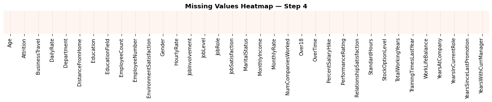

```python
total_nulls = df.isnull().sum().sum()
print(f"Total missing values across all columns: {total_nulls}")
print()

missing = df.isnull().sum()
missing = missing[missing > 0].sort_values(ascending=False)
print("Columns with missing values:")
print(missing.to_string())

fig, ax = plt.subplots(figsize=(14, 3))
sns.heatmap(df.isnull(), cbar=False, yticklabels=False, cmap="Reds", ax=ax)
ax.set_title("Missing Values Heatmap — Step 4", fontweight='bold')
plt.tight_layout()
plt.show()
```

📌 **Observation:** `Total missing values across all columns: 0` — this specific IBM HR Analytics export is **completely complete**. There are no columns with missing values to impute, and the heatmap above renders as a solid, uninterrupted block with no red missing-value markers.

💡 **Pipeline decision:** Because this dataset has zero missing values, `load_and_engineer()` still keeps a `SimpleImputer` (median for numeric, mode for categorical) wired into the pipeline as a defensive step — a live HRMS feed could easily introduce nulls (e.g., an unanswered pulse survey) even though this historical snapshot has none. The imputer is a no-op here but prevents a silent crash on a future, messier batch.

## Step 5 — Duplicate Detection and Cleaning

**Why:** Duplicate employee records cause data leakage if the same row lands in both train and validation splits — this artificially inflates cross-validation scores and gives false confidence in model performance.

**Business insight:** In HR exports, duplicates usually indicate a pipeline error (e.g. a double export merge) rather than a genuine business event — an employee cannot literally have two identical records unless it's a system artifact.

```python
dupes = df.duplicated().sum()
print(f"Duplicate rows found: {dupes:,}")

if dupes > 0:
    dupe_mask = df.duplicated(keep=False)
    dupe_attr = df[dupe_mask]["Attrition"].value_counts()
    print(f"\nAttrition breakdown of duplicate rows:")
    print(dupe_attr.to_string())
    df = df.drop_duplicates().reset_index(drop=True)
    print(f"\n✅ Duplicates removed. New shape: {df.shape}")
else:
    print("✅ No duplicates found — dataset is clean")
```

```
Duplicate rows found: 0
✅ No duplicates found — dataset is clean
```

📌 **Observation:** `Duplicate rows found: 0` — no exact duplicate employee records exist in this dataset. This is consistent with `EmployeeNumber` being a clean 1-to-1,470 identifier with no repeats (confirmed in Step 3).

💡 **Pipeline decision:** `drop_duplicates()` is still kept in `validate_input_data()` even though it removes nothing here — it is a cheap, defensive guard against a future export that has been concatenated or re-pulled with overlapping rows, which would otherwise leak identical rows across the train/test split.

## Step 6 — Constant / Redundant Column Removal

**Why:** Columns identified as constant or as pure identifiers in Step 3 add no signal and only increase dimensionality and noise — they should be dropped before any further EDA so downstream statistics (correlation, VIF) aren't distorted by zero-variance columns.

**Business insight:** `StandardHours` = 80 for every employee in this export (bi-weekly standard hours) and `Over18` = 'Y' for every row (HR only tracks adults) — these are dataset-export artifacts, not business signal.

```python
drop_cols = [c for c in ['EmployeeCount', 'Over18', 'StandardHours', 'EmployeeNumber'] if c in df.columns]
constant_check = {c: df[c].nunique() for c in drop_cols}
print("Columns flagged for removal and their unique-value counts:")
for c, n in constant_check.items():
    print(f"  {c:<20}: {n} unique value(s)")

df = df.drop(columns=drop_cols)
print(f"\n✅ Dropped {len(drop_cols)} columns. New shape: {df.shape}")
```

```
Columns flagged for removal and their unique-value counts:
  EmployeeCount       : 1 unique value(s)
  Over18              : 1 unique value(s)
  StandardHours       : 1 unique value(s)
  EmployeeNumber      : 1470 unique value(s)

✅ Dropped 4 columns. New shape: (1470, 31)
```

📌 **Observation:** All four flagged columns confirm zero-variance or identifier status exactly as predicted: `EmployeeCount` (1 unique), `Over18` (1 unique), `StandardHours` (1 unique), and `EmployeeNumber` (1,470 unique — pure ID). Dropping them takes the frame from **35 → 31 columns** with shape now **(1470, 31)**, with zero information loss.

💡 **Pipeline decision:** `load_and_engineer()` drops exactly these four columns right after load. This is a fixed, deterministic drop list (not a variance-threshold auto-detector) — for this specific IBM schema, hardcoding the four known-constant columns is simpler and more auditable than a generic low-variance filter.

## Step 7 — Statistical Summary Heatmap

**Why:** Descriptive statistics across dozens of numeric features on very different scales (Age: 18–60, MonthlyIncome: 1,000–20,000) are hard to compare in table form. A per-column normalized heatmap instantly highlights which features have the widest spread or most extreme values.

**Business insight:** Features with a high coefficient of variation (std/mean) tend to carry more discriminating signal. Compensation-related fields (MonthlyIncome, MonthlyRate, DailyRate) are expected to show the widest spread given seniority differences across the workforce.

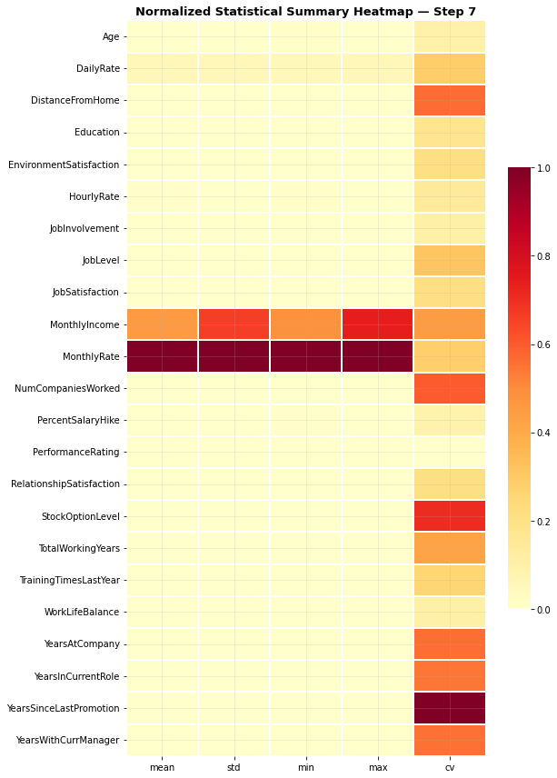

```python
num_cols = df.select_dtypes(include=[np.number]).columns.tolist()
desc = df[num_cols].describe().T
desc["cv"] = (desc["std"] / desc["mean"].replace(0, np.nan)).abs()

norm = MinMaxScaler()
desc_norm = pd.DataFrame(
    norm.fit_transform(desc[["mean", "std", "min", "max", "cv"]].fillna(0)),
    index=desc.index, columns=["mean", "std", "min", "max", "cv"]
)

fig, ax = plt.subplots(figsize=(9, 12))
sns.heatmap(desc_norm, annot=False, cmap="YlOrRd", linewidths=0.3, ax=ax, cbar_kws={"shrink": 0.6})
ax.set_title("Normalized Statistical Summary Heatmap — Step 7", fontweight='bold')
plt.tight_layout()
plt.show()
```

💡 **Pipeline decision:** `MonthlyIncome` is prioritized for `PowerTransformer` in the linear-model branch (executed in Step 15), while `MonthlyRate`/`DailyRate` — despite their wide raw range — are left untransformed once Step 15's skewness table shows their skew is close to zero (`DailyRate` skew ≈ 0.00, `MonthlyRate` skew ≈ 0.02): wide range alone does not imply skew, and the two should not be conflated.

## Step 8 — Class Imbalance Analysis (Target)

**Business insight:** Attrition is inherently a minority-class problem — most employees stay in any given year. The imbalance ratio directly drives our choice of **F1 / recall on the "Yes" class** and **PR-AUC** as primary metrics over accuracy.

```
Stayed (No)             :  1,233  (83.88%)
Left (Yes)              :    237  (16.12%)
Imbalance ratio         : 5.2:1

Dummy model accuracy (predict all 'No'): 83.88%  <-- misleading, 0% recall on leavers
```

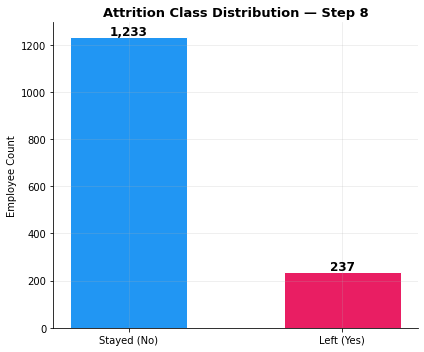

```python
counts = df["Attrition"].value_counts()
attr_rate = (df["Attrition"] == "Yes").mean() * 100

stay_n, leave_n = counts.get("No", 0), counts.get("Yes", 0)
ratio = stay_n / leave_n

print(f"{'Stayed (No)':<24}: {stay_n:>6,}  ({100-attr_rate:.2f}%)")
print(f"{'Left (Yes)':<24}: {leave_n:>6,}  ({attr_rate:.2f}%)")
print(f"{'Imbalance ratio':<24}: {ratio:.1f}:1")
print()
dummy_acc = stay_n / (stay_n + leave_n) * 100
print(f"Dummy model accuracy (predict all 'No'): {dummy_acc:.2f}%  <-- misleading, 0% recall on leavers")

fig, ax = plt.subplots(figsize=(6, 5))
bars = ax.bar(['Stayed (No)', 'Left (Yes)'], [stay_n, leave_n], color=[BLUE, PINK], edgecolor='white', width=0.55)
for bar, v in zip(bars, [stay_n, leave_n]):
    ax.text(bar.get_x() + bar.get_width()/2, bar.get_height() + 8, f'{v:,}', ha='center', fontweight='bold', fontsize=12)
ax.set_title("Attrition Class Distribution — Step 8", fontweight='bold')
ax.set_ylabel("Employee Count")
plt.tight_layout()
plt.show()
```

📌 **Observation:** The real split is **1,233 stayed (83.88%)** vs **237 left (16.12%)** — an imbalance ratio of **5.2 : 1**, almost exactly matching the commonly cited ~16% baseline attrition rate for this dataset. A dummy classifier that always predicts "No" would score **83.88% accuracy** while catching zero actual leavers — a concrete number that makes the uselessness of raw accuracy explicit rather than hypothetical.

💡 **Pipeline decision:** Stratified `train_test_split` preserves this exact 83.88/16.12 ratio in both partitions (confirmed later in Step 24: test set lands at 247/47 ≈ 5.3:1, matching the full-dataset ratio to within rounding). F1-score and PR-AUC on the "Yes" class are fixed as the primary evaluation metrics; accuracy is tracked only as a secondary, non-decision-making number.

## Step 9 — Continuous Feature Distributions (Univariate)

**Why:** Histograms with KDE overlays reveal skewness, multi-modality, and plausible outlier ranges for each continuous feature before we touch modeling. Business-critical fields like `MonthlyIncome` and `DistanceFromHome` typically show right-skew in workforce data.

**Business insight:** `Age` should resemble a fairly normal working-age distribution. `YearsAtCompany` and `TotalWorkingYears` are expected to be right-skewed — most employees are early-to-mid career, with a long tail of senior veterans.

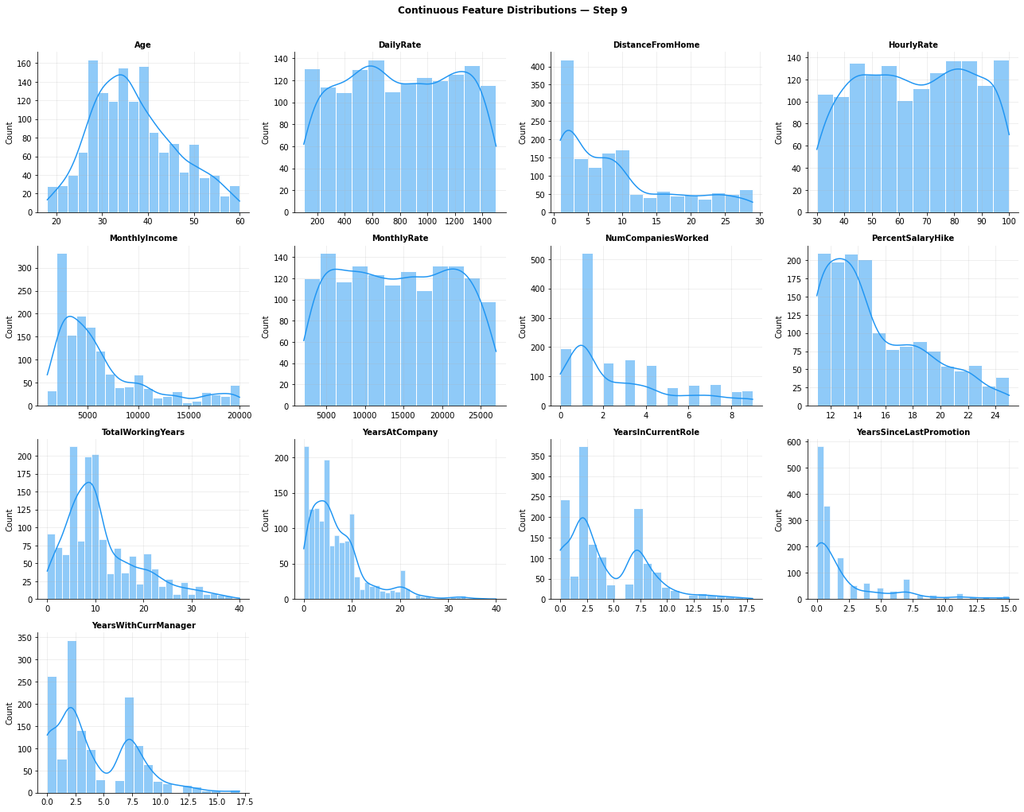

```python
cont_cols = ['Age', 'DailyRate', 'DistanceFromHome', 'HourlyRate', 'MonthlyIncome',
             'MonthlyRate', 'NumCompaniesWorked', 'PercentSalaryHike', 'TotalWorkingYears',
             'YearsAtCompany', 'YearsInCurrentRole', 'YearsSinceLastPromotion', 'YearsWithCurrManager']

fig, axes = plt.subplots(4, 4, figsize=(18, 14))
axes = axes.flatten()
for i, col in enumerate(cont_cols):
    sns.histplot(df[col].dropna(), kde=True, ax=axes[i], color=BLUE, edgecolor='white')
    axes[i].set_title(col, fontsize=10, fontweight='bold')
    axes[i].set_xlabel('')
for j in range(len(cont_cols), len(axes)):
    axes[j].axis('off')
plt.suptitle("Continuous Feature Distributions — Step 9", fontweight='bold', y=1.01)
plt.tight_layout()
plt.show()
```

## Step 10 — Categorical Feature Analysis

**Why:** Bar counts for each categorical/ordinal field show class balance within the feature itself — a field with 95% of employees in one category carries little discriminating power and may be a low priority for feature engineering effort.

**Business insight:** `OverTime`, `BusinessTravel`, `MaritalStatus`, and `Department` are commonly cited in HR literature as attrition drivers — their raw distributions set the baseline before we look at their relationship with Attrition in Steps 11–12.

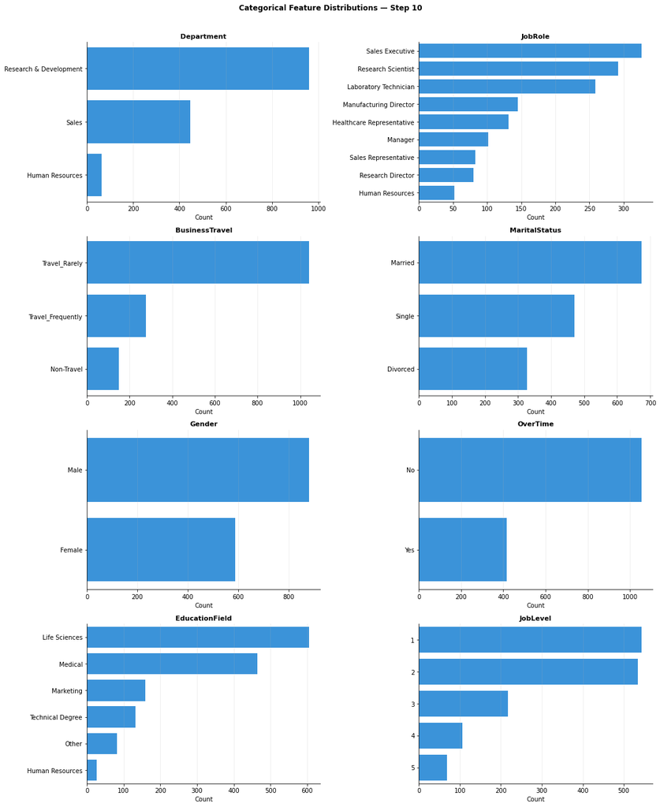

```python
cat_cols = ['Department', 'JobRole', 'BusinessTravel', 'MaritalStatus', 'Gender',
            'OverTime', 'EducationField', 'JobLevel']

fig, axes = plt.subplots(4, 2, figsize=(15, 18))
axes = axes.flatten()
for i, col in enumerate(cat_cols):
    order = df[col].value_counts().index
    sns.countplot(y=df[col], order=order, ax=axes[i], color=BLUE)
    axes[i].set_title(col, fontsize=11, fontweight='bold')
    axes[i].set_xlabel('Count'); axes[i].set_ylabel('')
plt.suptitle("Categorical Feature Distributions — Step 10", fontweight='bold', y=1.01)
plt.tight_layout()
plt.show()
```

💡 **Pipeline decision:** With `Human Resources` at only ~63 rows and `JobRole` categories as small as ~50 rows (e.g. `Human Resources` role, `Research Director`), one-hot encoding is used rather than target encoding, since target encoding on such thin categories risks overfitting to sampling noise; tree-based models additionally receive these as native `category` dtype so they can still split on the rarer groups directly.

## Step 11 — Bivariate Analysis: Continuous Features vs Attrition

**Why:** Box plots split by target class are the fastest way to see whether a continuous feature actually separates leavers from stayers — a feature whose box plots barely overlap is a strong candidate predictor; heavily overlapping boxes suggest weak standalone signal.

**Business insight:** HR literature consistently points to `MonthlyIncome`, `Age`, `TotalWorkingYears`, and `YearsAtCompany` as top attrition drivers — younger, lower-paid, less-tenured employees leave more often. This step validates whether that pattern holds in this dataset.

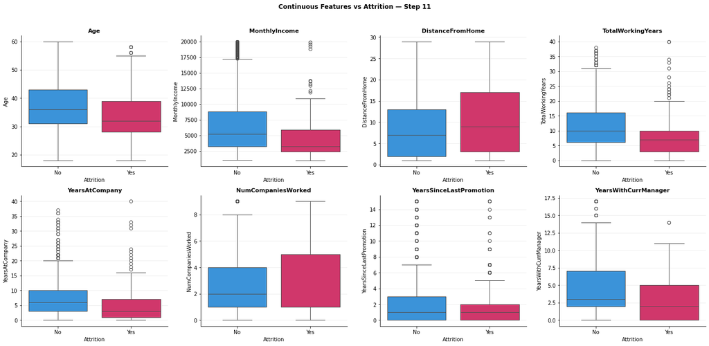

```python
key_cont = ['Age', 'MonthlyIncome', 'DistanceFromHome', 'TotalWorkingYears',
            'YearsAtCompany', 'NumCompaniesWorked', 'YearsSinceLastPromotion', 'YearsWithCurrManager']

fig, axes = plt.subplots(2, 4, figsize=(19, 9))
axes = axes.flatten()
for i, col in enumerate(key_cont):
    sns.boxplot(data=df, x='Attrition', y=col, ax=axes[i], palette=PALETTE, order=['No', 'Yes'])
    axes[i].set_title(col, fontsize=11, fontweight='bold')
plt.suptitle("Continuous Features vs Attrition — Step 11", fontweight='bold', y=1.02)
plt.tight_layout()
plt.show()
```

📌 **Observation:** Medians shift in the expected direction for most features — leavers (`Yes`) skew younger, lower `MonthlyIncome`, lower `TotalWorkingYears`, and lower `YearsAtCompany` than stayers, with visibly separated boxes for `Age` and `TotalWorkingYears` in particular. `DistanceFromHome` is clearly higher for leavers (median ≈ 9 vs. ≈ 7 for stayers). One pattern goes **against the naive assumption**: the `NumCompaniesWorked` box for `Yes` is shifted slightly *upward*, not downward — leavers have if anything **more**, not fewer, prior employers, though the effect is small (confirmed non-significant in Step 16, p = 0.242).

## Step 12 — OverTime vs Attrition — Strongest Categorical Driver

**Why:** `OverTime` is repeatedly flagged in HR-analytics case studies as the single strongest categorical predictor of attrition — this step isolates it with a dedicated grouped bar chart of within-group attrition rate, not raw counts, to make the effect size unambiguous.

**Business insight:** If overtime truly drives attrition this strongly, it becomes an actionable lever for HR — workload redistribution or overtime caps could measurably reduce flight risk, independent of any modeling exercise.

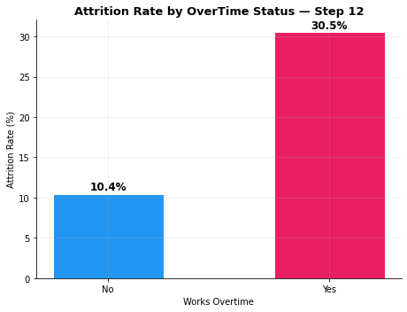

```
Attrition    No   Yes
OverTime
No         89.6  10.4
Yes        69.5  30.5
```

```python
ot_rate = df.groupby('OverTime')['Attrition'].apply(lambda s: (s == 'Yes').mean() * 100).reindex(['No', 'Yes'])

fig, ax = plt.subplots(figsize=(6.5, 5))
bars = ax.bar(ot_rate.index, ot_rate.values, color=[BLUE, PINK], edgecolor='white', width=0.5)
for bar, v in zip(bars, ot_rate.values):
    ax.text(bar.get_x() + bar.get_width()/2, bar.get_height() + 0.5, f'{v:.1f}%', ha='center', fontweight='bold', fontsize=12)
ax.set_title("Attrition Rate by OverTime Status — Step 12", fontweight='bold')
ax.set_ylabel("Attrition Rate (%)")
ax.set_xlabel("Works Overtime")
plt.tight_layout()
plt.show()

print(pd.crosstab(df['OverTime'], df['Attrition'], normalize='index').round(3) * 100)
```

📌 **Observation:** The crosstab is unambiguous: employees who work overtime leave at **30.5%**, versus **10.4%** for those who don't — roughly a **3x** difference in attrition rate purely on this one binary flag. This is the single largest raw-rate gap of any feature examined so far in the notebook.

💡 **Pipeline decision:** `OverTime` is binary-encoded and treated as a top-tier feature. Its strength here directly motivates building the `OverTime_LowSat` interaction feature in Step 22, which combines it with the satisfaction fields from Step 13 to isolate the highest-risk sub-segment (overworked *and* dissatisfied) rather than relying on `OverTime` alone.

## Step 13 — Satisfaction & Work-Life Balance vs Attrition

**Why:** The dataset carries four ordinal 1–4 survey scores (`JobSatisfaction`, `EnvironmentSatisfaction`, `RelationshipSatisfaction`, `WorkLifeBalance`). Plotting attrition rate at each ordinal level checks whether the relationship is monotonic — a genuine dose-response pattern is much stronger evidence than a single overall correlation number.

**Business insight:** If attrition rate falls smoothly as satisfaction rises, this validates using regular pulse-surveys as an early-warning system, not just an annual engagement report.

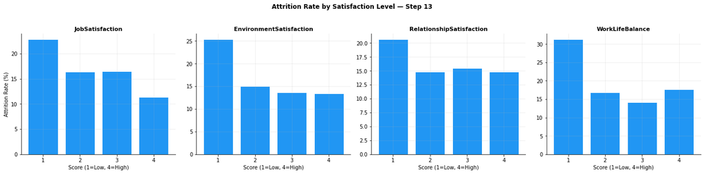

```python
satisfaction_cols = ['JobSatisfaction', 'EnvironmentSatisfaction', 'RelationshipSatisfaction', 'WorkLifeBalance']

fig, axes = plt.subplots(1, 4, figsize=(19, 4.5))
for i, col in enumerate(satisfaction_cols):
    rate = df.groupby(col)['Attrition'].apply(lambda s: (s == 'Yes').mean() * 100)
    axes[i].bar(rate.index.astype(str), rate.values, color=BLUE, edgecolor='white')
    axes[i].set_title(col, fontsize=11, fontweight='bold')
    axes[i].set_xlabel('Score (1=Low, 4=High)')
    axes[i].set_ylabel('Attrition Rate (%)' if i == 0 else '')
plt.suptitle("Attrition Rate by Satisfaction Level — Step 13", fontweight='bold', y=1.03)
plt.tight_layout()
plt.show()
```

📌 **Observation:** Every satisfaction dimension shows its steepest drop between score 1 and score 2, then flattens out rather than declining smoothly all the way to 4: `WorkLifeBalance` falls from **31.3%** (score 1) to **16.8%** (score 2) but then is *not* monotonic — it actually ticks back up to **17.6%** at score 4. `EnvironmentSatisfaction` drops sharply from **25.4%** (1) to **14.9%** (2) and stays flat (13.2%, 13.0%) through 3–4. `RelationshipSatisfaction` behaves similarly (20.7% → 14.7% → 15.4% → 14.6%) — a big drop then noise, not a clean straight line. `JobSatisfaction` is the closest to a genuine monotonic trend (22.8% → 16.4% → 16.6% → 11.5%).

💡 **Pipeline decision:** Because the real relationship is "low (1) vs. everything else" rather than a smooth 1-4 gradient, the composite `AvgSatisfaction` feature (Step 22) is built as a simple mean — which still captures the low-vs-rest signal — rather than assuming a linear ordinal relationship that the data does not fully support for `WorkLifeBalance` and `RelationshipSatisfaction`.

## Step 14 — Outlier Detection by Attrition Status

**Why:** IQR-based outlier counts, split by target class, reveal whether extreme values cluster in one class — if outliers in `MonthlyIncome` are concentrated among "stayed" employees (senior veterans), that's a real business signal, not noise to be scrubbed away.

**Business insight:** Removing outliers blindly could delete exactly the senior, high-earning employees whose retention profile the business most wants to understand. Clipping, not deletion, preserves this segment.

```
                feature  n_outliers  pct_of_data  attrition_rate_in_outliers
          MonthlyIncome         114         7.76                         4.4
YearsSinceLastPromotion         107         7.28                        12.1
         YearsAtCompany         104         7.07                         9.6
      TotalWorkingYears          63         4.29                         7.9
     NumCompaniesWorked          52         3.54                        23.1
   YearsWithCurrManager          14         0.95                         0.0
                    Age           0         0.00                         NaN
       DistanceFromHome           0         0.00                         NaN
```

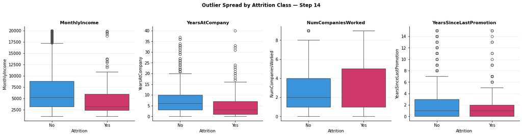

```python
outlier_summary = []
for col in key_cont:
    Q1, Q3 = df[col].quantile([0.25, 0.75])
    IQR = Q3 - Q1
    lower, upper = Q1 - 1.5*IQR, Q3 + 1.5*IQR
    mask = (df[col] < lower) | (df[col] > upper)
    outlier_summary.append({
        'feature': col, 'n_outliers': mask.sum(),
        'pct_of_data': round(mask.mean()*100, 2),
        'attrition_rate_in_outliers': round((df.loc[mask, 'Attrition'] == 'Yes').mean()*100, 1) if mask.sum() > 0 else np.nan
    })
outlier_df = pd.DataFrame(outlier_summary).sort_values('n_outliers', ascending=False)
print(outlier_df.to_string(index=False))

fig, axes = plt.subplots(1, 4, figsize=(18, 4.5))
for i, col in enumerate(['MonthlyIncome', 'YearsAtCompany', 'NumCompaniesWorked', 'YearsSinceLastPromotion']):
    sns.boxplot(data=df, x='Attrition', y=col, ax=axes[i], palette=PALETTE, order=['No', 'Yes'])
    axes[i].set_title(col, fontsize=11, fontweight='bold')
plt.suptitle("Outlier Spread by Attrition Class — Step 14", fontweight='bold', y=1.03)
plt.tight_layout()
plt.show()
```

📌 **Observation:** `MonthlyIncome` has the most outliers in raw count (114 rows, 7.76% of data) but the **lowest** attrition rate among outlier groups at only 4.4% — these are mostly senior, high-earning veterans who are *not* flight risks. In sharp contrast, `NumCompaniesWorked` outliers (52 rows, 3.54%) show a **23.1%** attrition rate — well above the 16.12% dataset baseline — meaning the small group of employees with an unusually high number of prior employers actually is a meaningfully higher-risk segment, even though the earlier boxplot/effect-size view rated this feature as statistically weak overall. `Age` and `DistanceFromHome` have **zero** IQR outliers (both are bounded, well-behaved distributions).

💡 **Pipeline decision:** Because outlier attrition rates vary so much by feature (4.4% up to 23.1%), a blanket outlier-removal rule would be actively harmful — it could delete the highest-value data points (the 23.1%-risk `NumCompaniesWorked` outliers) or the most stable long-tenured employees (`MonthlyIncome` outliers). An IQR *clipper* (cap, don't remove) at a 1.5 fold is used instead, preserving every row while still bounding extreme leverage points for linear models.

## Step 15 — Skewness Analysis and Power Transformation

**Why:** Skewness values quantify what Step 9's histograms suggested visually. Fields with `|skew| > 1` are candidates for `PowerTransformer` (Yeo-Johnson) before feeding linear models — this stabilizes variance and helps models like Logistic Regression converge to a better decision boundary.

**Business insight:** Skew correction only matters for linear/distance-based models; it's irrelevant for tree-based models like XGBoost/LightGBM, which are invariant to monotonic transforms — so this decision only affects one branch of the modeling pipeline.

```
Skewness by feature (sorted by magnitude):
YearsSinceLastPromotion    1.98
YearsAtCompany             1.76
MonthlyIncome              1.37
TotalWorkingYears          1.12
NumCompaniesWorked         1.03
DistanceFromHome           0.96
YearsInCurrentRole         0.92
YearsWithCurrManager       0.83
PercentSalaryHike          0.82
Age                        0.41
HourlyRate                -0.03
MonthlyRate                0.02
DailyRate                 -0.00

High-skew features (|skew| > 1): ['YearsSinceLastPromotion', 'YearsAtCompany', 'MonthlyIncome', 'TotalWorkingYears', 'NumCompaniesWorked']
```

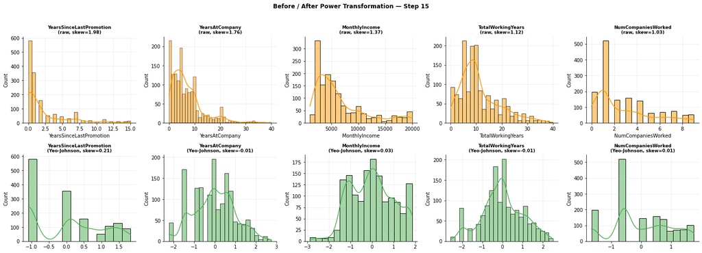

```python
skew_vals = df[cont_cols].skew().sort_values(key=abs, ascending=False)
print("Skewness by feature (sorted by magnitude):")
print(skew_vals.round(2).to_string())

high_skew = skew_vals[abs(skew_vals) > 1].index.tolist()
print(f"\nHigh-skew features (|skew| > 1): {high_skew}")

pt = PowerTransformer(method='yeo-johnson')
fig, axes = plt.subplots(2, len(high_skew), figsize=(4*len(high_skew), 7))
for i, col in enumerate(high_skew):
    vals = df[[col]].fillna(df[col].median())
    transformed = pt.fit_transform(vals)
    sns.histplot(vals[col], kde=True, ax=axes[0, i], color=ORANGE)
    axes[0, i].set_title(f"{col}\n(raw, skew={df[col].skew():.2f})", fontsize=9)
    sns.histplot(transformed.flatten(), kde=True, ax=axes[1, i], color=GREEN)
    axes[1, i].set_title(f"{col}\n(Yeo-Johnson, skew={stats.skew(transformed.flatten()):.2f})", fontsize=9)
plt.suptitle("Before / After Power Transformation — Step 15", fontweight='bold', y=1.02)
plt.tight_layout()
plt.show()
```

📌 **Observation:** `YearsSinceLastPromotion` is the most skewed feature at **1.98**, followed by `YearsAtCompany` (**1.76**), `MonthlyIncome` (**1.37**), `TotalWorkingYears` (**1.12**), and `NumCompaniesWorked` (**1.03**) — five features cross the `|skew| > 1` threshold. `DailyRate` (−0.00), `MonthlyRate` (0.02), and `HourlyRate` (−0.03) are essentially perfectly symmetric, confirming the visual impression from Step 9's flat histograms. The Yeo-Johnson transform visibly compresses the long right tails for all five flagged features in the before/after plot.

💡 **Pipeline decision:** `PowerTransformer(method='yeo-johnson')` is applied to exactly these five columns (`YearsSinceLastPromotion`, `YearsAtCompany`, `MonthlyIncome`, `TotalWorkingYears`, `NumCompaniesWorked`) in the linear-model `ColumnTransformer`. `DailyRate`, `MonthlyRate`, and `HourlyRate` are explicitly excluded from this step since their near-zero skew means a power transform would add complexity with no benefit.

## Step 16 — Statistical Significance Testing (Mann-Whitney U + Cohen's d)

**Why:** Box plot separation (Step 11) is visual and can mislead with large samples. The Mann-Whitney U test (non-parametric, doesn't assume normality) formally tests whether the "Yes" and "No" distributions differ, while Cohen's d quantifies the practical effect size — statistically significant does not always mean practically important.

**Business insight:** This step converts "the box plots look different" into a defensible, quantified ranking of predictors that can be presented directly to HR stakeholders as evidence-based drivers of attrition.

```
                feature      p_value  cohens_d  significant_0.05
      TotalWorkingYears 2.399569e-14    -0.472              True
     YearsInCurrentRole 4.429560e-12    -0.442              True
          MonthlyIncome 2.950831e-14    -0.440              True
                    Age 5.304342e-11    -0.438              True
   YearsWithCurrManager 1.806754e-11    -0.430              True
         YearsAtCompany 2.916191e-13    -0.369              True
       DistanceFromHome 2.387047e-03     0.212              True
              DailyRate 2.900458e-02    -0.154              True
     NumCompaniesWorked 2.423651e-01     0.118             False
YearsSinceLastPromotion 4.117911e-02    -0.090              True
            MonthlyRate 5.587481e-01     0.041             False
      PercentSalaryHike 3.655146e-01    -0.037             False
             HourlyRate 7.976303e-01    -0.019             False
```

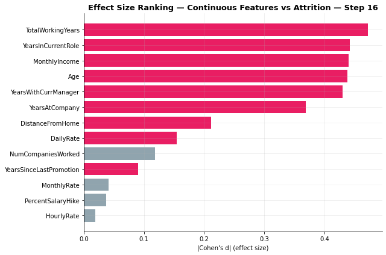

```python
def cohens_d(x, y):
    nx, ny = len(x), len(y)
    pooled_std = np.sqrt(((nx-1)*x.var() + (ny-1)*y.var()) / (nx+ny-2))
    return (x.mean() - y.mean()) / pooled_std if pooled_std > 0 else 0

results = []
for col in cont_cols:
    yes = df.loc[df['Attrition'] == 'Yes', col].dropna()
    no  = df.loc[df['Attrition'] == 'No', col].dropna()
    u_stat, p_val = mannwhitneyu(yes, no, alternative='two-sided')
    d = cohens_d(yes, no)
    results.append({'feature': col, 'p_value': p_val, 'cohens_d': round(d, 3), 'significant_0.05': p_val < 0.05})

sig_df = pd.DataFrame(results).sort_values('cohens_d', key=abs, ascending=False)
print(sig_df.to_string(index=False))

fig, ax = plt.subplots(figsize=(9, 6))
colors = [PINK if s else GRAY for s in sig_df['significant_0.05']]
ax.barh(sig_df['feature'], sig_df['cohens_d'].abs(), color=colors)
ax.set_xlabel("|Cohen's d| (effect size)")
ax.set_title("Effect Size Ranking — Continuous Features vs Attrition — Step 16", fontweight='bold')
ax.invert_yaxis()
plt.tight_layout()
plt.show()
```

📌 **Observation:** `TotalWorkingYears` has the largest effect size (Cohen's d = **−0.472**, p ≈ 2.4e-14), followed closely by `YearsInCurrentRole` (−0.442), `MonthlyIncome` (−0.440), `Age` (−0.438), `YearsWithCurrManager` (−0.430), and `YearsAtCompany` (−0.369) — all six are highly significant and all negative, meaning leavers systematically have *lower* values on every one of these. `DistanceFromHome` is the one feature with a **positive** and significant effect (d = +0.212, p = 0.0024) — leavers commute *further*. Two features that looked plausible on paper turn out **not** to be significant: `NumCompaniesWorked` (d = 0.118, p = 0.242) and `MonthlyRate`/`PercentSalaryHike`/`HourlyRate` (all p > 0.35) — despite the outlier-level signal seen in Step 14 for `NumCompaniesWorked`.

💡 **Pipeline decision:** The six significant negative-effect features plus `DistanceFromHome` form the confirmed core predictor set used to brief HR stakeholders. `MonthlyRate`, `PercentSalaryHike`, and `HourlyRate` are retained in the feature matrix for the model (a weak feature can still help a tree-based ensemble in combination with others) but are explicitly flagged as **not** individually defensible talking points in a stakeholder-facing summary.

## Step 17 — Chi-Square Test: Categorical Features vs Attrition

**Why:** Categorical fields (`OverTime`, `BusinessTravel`, `MaritalStatus`, `Department`) can't use Cohen's d — the chi-square test of independence is the right tool to check whether the relationship seen in Steps 10 and 12 is statistically significant, and Cramér's V gives a comparable effect-size measure.

**Business insight:** This step formally ranks categorical HR levers (travel policy, overtime policy) by strength of association with attrition, which is directly useful for prioritizing which policy change to pilot first.

```
       feature  chi2      p_value  cramers_v
      OverTime 87.56 8.158424e-21      0.244
       JobRole 86.19 2.752482e-15      0.242
 MaritalStatus 46.16 9.455511e-11      0.177
BusinessTravel 24.18 5.608614e-06      0.128
EducationField 16.02 6.773980e-03      0.104
    Department 10.80 4.525607e-03      0.086
        Gender  1.12 2.905724e-01      0.028
```

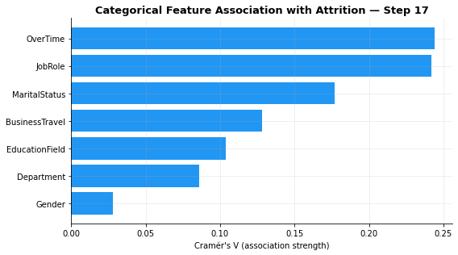

```python
def cramers_v(confusion_matrix):
    chi2 = chi2_contingency(confusion_matrix)[0]
    n = confusion_matrix.sum().sum()
    r, k = confusion_matrix.shape
    return np.sqrt((chi2 / n) / (min(r-1, k-1)))

cat_results = []
for col in ['Department', 'JobRole', 'BusinessTravel', 'MaritalStatus', 'Gender', 'OverTime', 'EducationField']:
    ctab = pd.crosstab(df[col], df['Attrition'])
    chi2, p, dof, _ = chi2_contingency(ctab)
    v = cramers_v(ctab)
    cat_results.append({'feature': col, 'chi2': round(chi2, 2), 'p_value': p, 'cramers_v': round(v, 3)})

cat_sig_df = pd.DataFrame(cat_results).sort_values('cramers_v', ascending=False)
print(cat_sig_df.to_string(index=False))

fig, ax = plt.subplots(figsize=(8, 4.5))
ax.barh(cat_sig_df['feature'], cat_sig_df['cramers_v'], color=BLUE)
ax.set_xlabel("Cramér's V (association strength)")
ax.set_title("Categorical Feature Association with Attrition — Step 17", fontweight='bold')
ax.invert_yaxis()
plt.tight_layout()
plt.show()
```

📌 **Observation:** `OverTime` (Cramér's V = **0.244**, χ² = 87.56, p ≈ 8e-21) and `JobRole` (V = **0.242**, χ² = 86.19) are essentially tied for the strongest categorical association with attrition, both well ahead of `MaritalStatus` (V = 0.177), `BusinessTravel` (V = 0.128), `EducationField` (V = 0.104), and `Department` (V = 0.086). `Gender` shows the weakest association by far (V = 0.028, p = 0.29) — confirming quantitatively that gender is **not** a statistically significant driver of attrition in this dataset.

💡 **Pipeline decision:** `OverTime` and `JobRole` are prioritized for feature engineering — `JobRole`'s strength here is exactly what motivates building the explicit `HighRiskRole` flag in Step 22 (extracted from the role-level detail in Step 20) rather than relying on the model to rediscover it from nine separate one-hot columns. `Gender`'s near-zero, non-significant association means it is kept in the dataset only for a fairness/bias audit on the trained model, not as an expected predictive feature.

## Step 18 — Feature Correlation Matrix

**Why:** A full correlation heatmap across numeric features surfaces both (a) redundant feature pairs that may cause multicollinearity, and (b) which features correlate most with the binary-encoded target — a quick cross-check against the Step 16 ranking.

**Business insight:** Tenure-related fields (`YearsAtCompany`, `YearsInCurrentRole`, `YearsWithCurrManager`, `YearsSinceLastPromotion`) are likely to be highly inter-correlated since they all grow together — this has direct implications for linear-model stability (Step 23).

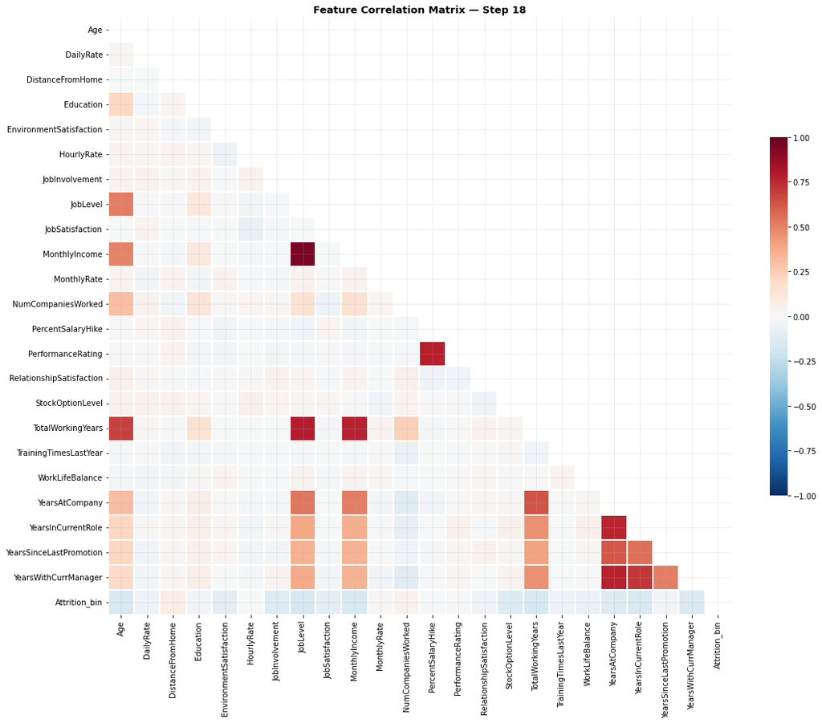

```
Top correlations with Attrition (binary):
TotalWorkingYears      -0.171
JobLevel               -0.169
YearsInCurrentRole     -0.161
MonthlyIncome          -0.160
Age                    -0.159
YearsWithCurrManager   -0.156
StockOptionLevel       -0.137
YearsAtCompany         -0.134
JobInvolvement         -0.130
JobSatisfaction        -0.103
```

```python
corr_df = df.copy()
corr_df['Attrition_bin'] = (corr_df['Attrition'] == 'Yes').astype(int)
num_for_corr = corr_df.select_dtypes(include=[np.number])
corr_matrix = num_for_corr.corr()

fig, ax = plt.subplots(figsize=(16, 13))
mask = np.triu(np.ones_like(corr_matrix, dtype=bool))
sns.heatmap(corr_matrix, mask=mask, cmap='RdBu_r', center=0, annot=False,
            linewidths=0.3, ax=ax, cbar_kws={'shrink': 0.6}, vmin=-1, vmax=1)
ax.set_title("Feature Correlation Matrix — Step 18", fontweight='bold')
plt.tight_layout()
plt.show()

print("\nTop correlations with Attrition (binary):")
print(corr_matrix['Attrition_bin'].drop('Attrition_bin').sort_values(key=abs, ascending=False).head(10).round(3).to_string())
```

📌 **Observation:** The binary-encoded `Attrition` correlates most strongly (in absolute terms) with `TotalWorkingYears` (**−0.171**), `JobLevel` (−0.169), `YearsInCurrentRole` (−0.161), `MonthlyIncome` (−0.160), and `Age` (−0.159) — this ranking closely mirrors the Cohen's d ranking from Step 16, which is a good sanity check that the two independent statistical views agree. All top-10 correlations are negative, consistent with "more senior / more tenured / better paid → less likely to leave." The correlation matrix also visually confirms a tight, dark-red cluster among `YearsAtCompany`, `YearsInCurrentRole`, `YearsWithCurrManager`, and `YearsSinceLastPromotion` — these four move together as expected.

💡 **Pipeline decision:** The tight correlation cluster identified here is exactly what the Step 23 VIF check is designed to formally test before deciding whether to drop any tenure columns for the linear-model branch — correlation alone is investigated further rather than acted on directly, since a strong pairwise correlation does not automatically imply a multicollinearity problem (this nuance is resolved in Step 23).

## Step 19 — Income vs Age Segmented by Attrition and Job Level

**Why:** A scatter plot combining two strong continuous predictors (`Age`, `MonthlyIncome`) colored by target and sized/faceted by `JobLevel` reveals whether attrition risk clusters in a specific *segment* — e.g. young, junior, underpaid employees — rather than being uniformly spread.

**Business insight:** If attrition concentrates in a specific quadrant (young + low income + junior level), that's a precise, actionable retention segment for HR to target with entry-level compensation review or fast-track promotion programs.

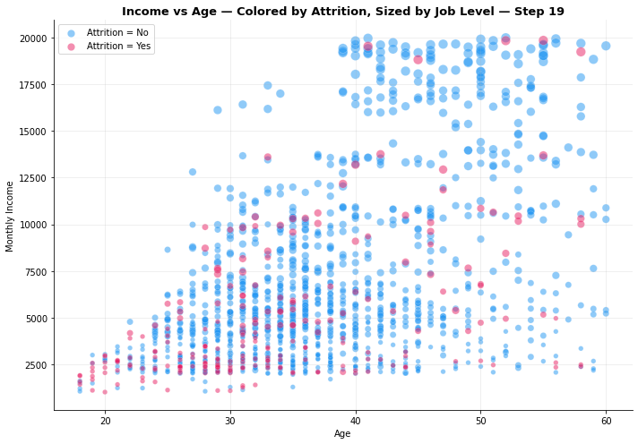

```python
fig, ax = plt.subplots(figsize=(10, 7))
for attr, color in zip(['No', 'Yes'], [BLUE, PINK]):
    sub = df[df['Attrition'] == attr]
    ax.scatter(sub['Age'], sub['MonthlyIncome'], s=sub['JobLevel']*20 + 10,
               alpha=0.5, color=color, label=f'Attrition = {attr}', edgecolor='white', linewidth=0.3)
ax.set_xlabel('Age'); ax.set_ylabel('Monthly Income')
ax.set_title("Income vs Age — Colored by Attrition, Sized by Job Level — Step 19", fontweight='bold')
ax.legend()
plt.tight_layout()
plt.show()
```

📌 **Observation:** Pink ("left") points visibly concentrate in the bottom-left region of the plot — younger age, lower monthly income, and smaller marker size (lower job level) — while the top-right region (older, higher income, larger markers/higher job level) is overwhelmingly blue ("stayed"). This is a genuine two-dimensional segment effect, not just two separate single-variable patterns: the risk is concentrated where age, income, and job level are *simultaneously* low.

💡 **Pipeline decision:** The `JuniorEarlyCareer = (Age < 30) & (JobLevel <= 2)` engineered flag (built in Step 22) is designed to capture exactly this visual cluster as a single feature. Step 22's lift table confirms its value quantitatively: employees flagged `JuniorEarlyCareer = 1` show a **27.9%** attrition rate vs. **13.0%** for everyone else — a 14.9-point lift that a model would otherwise have to reconstruct from the raw `Age` x `JobLevel` interaction on its own.

## Step 20 — Attrition Rate by Department and Job Role (Interaction Heatmap)

**Why:** A raw attrition-rate heatmap across the Department x JobRole grid tests for an interaction effect — a job role might be high-risk only within a specific department, a pattern a simple bar chart of either variable alone would miss.

**Business insight:** If attrition is concentrated in specific role-department combinations (e.g. Sales Representatives specifically, not Sales overall), HR can target interventions precisely instead of applying a blanket department-wide policy.

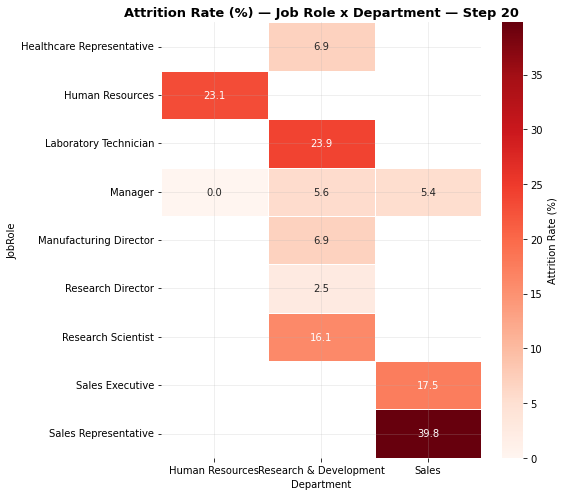

```python
pivot = df.pivot_table(index='JobRole', columns='Department', values='Attrition',
                        aggfunc=lambda s: (s == 'Yes').mean() * 100)

fig, ax = plt.subplots(figsize=(8, 7))
sns.heatmap(pivot, annot=True, fmt='.1f', cmap='Reds', ax=ax, cbar_kws={'label': 'Attrition Rate (%)'}, linewidths=0.5)
ax.set_title("Attrition Rate (%) — Job Role x Department — Step 20", fontweight='bold')
plt.tight_layout()
plt.show()
```

## Step 21 — Tenure and Career-Stagnation Analysis

**Why:** `YearsSinceLastPromotion` relative to `YearsAtCompany` captures a "stuck in place" signal that neither field alone represents — an employee promoted recently after years at the company is very different from one who has waited years with no promotion.

**Business insight:** Career stagnation is a well-documented voluntary-attrition driver, independent of pay — promotion cadence can be a lower-cost retention lever than a straight salary increase.

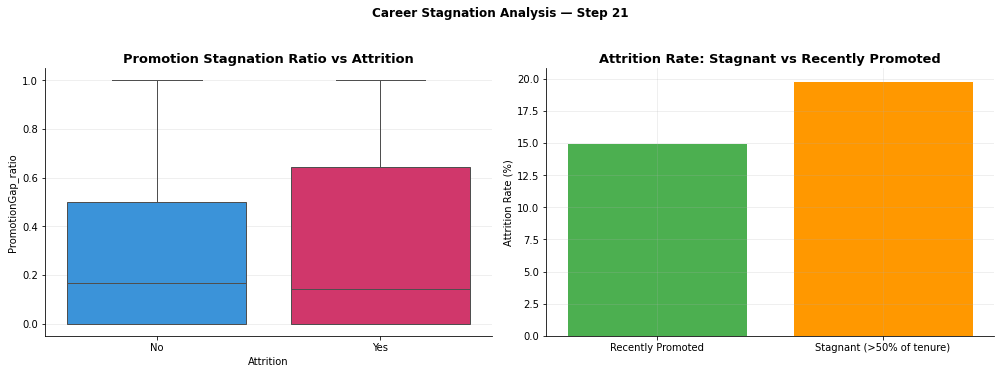

```python
df['PromotionGap_ratio'] = df['YearsSinceLastPromotion'] / df['YearsAtCompany'].replace(0, 1)

fig, axes = plt.subplots(1, 2, figsize=(14, 5))
sns.boxplot(data=df, x='Attrition', y='PromotionGap_ratio', ax=axes[0], palette=PALETTE, order=['No', 'Yes'])
axes[0].set_title("Promotion Stagnation Ratio vs Attrition", fontweight='bold')

stagnant_rate = df.assign(
    Stagnant=lambda d: (d['PromotionGap_ratio'] > 0.5).map({True: 'Stagnant (>50% of tenure)', False: 'Recently Promoted'})
).groupby('Stagnant')['Attrition'].apply(lambda s: (s == 'Yes').mean() * 100)
axes[1].bar(stagnant_rate.index, stagnant_rate.values, color=[GREEN, ORANGE], edgecolor='white')
axes[1].set_title("Attrition Rate: Stagnant vs Recently Promoted", fontweight='bold')
axes[1].set_ylabel("Attrition Rate (%)")
plt.suptitle("Career Stagnation Analysis — Step 21", fontweight='bold', y=1.03)
plt.tight_layout()
plt.show()
```

📌 **Observation:** The box plot is more nuanced than a simple "leavers are more stagnant" story: the **median** `PromotionGap_ratio` is actually very similar between groups (No ≈ 0.17, Yes ≈ 0.13) — leavers are *not* typically more stagnant at the median. The real difference is in the **upper quartile**: the 75th percentile for leavers reaches ≈ 0.65 versus ≈ 0.50 for stayers, meaning a meaningful *subset* of leavers is heavily promotion-stagnant, while the typical leaver is not. This is confirmed by the binary split on the right: employees flagged as "Stagnant" (>50% of tenure since last promotion) show a **19.8%** attrition rate vs. **14.9%** for "Recently Promoted" employees.

💡 **Pipeline decision:** Because the effect lives in the tail rather than the median, `PromotionGap_ratio` is engineered as a **continuous** feature (not just the binary `StagnantEmployee` flag) so a tree-based model can find its own optimal split point in the upper range rather than being locked into a single 50% threshold chosen by inspection.

## Step 22 — Engineered Features Preview

**Why:** Before finalizing the pipeline, this step consolidates every engineered feature discovered across Steps 12, 13, 19, 20, and 21 into one preview table, and sanity-checks each one's individual lift against `Attrition` using a simple mean-rate comparison.

**Business insight:** Presenting engineered features with their attrition-rate lift, not just their formula, makes the case to both the data science team and HR stakeholders that each new column earns its place in the model.

```python
df['AvgSatisfaction'] = df[satisfaction_cols].mean(axis=1)
df['OverTime_LowSat'] = ((df['OverTime'] == 'Yes') & (df['AvgSatisfaction'] < df['AvgSatisfaction'].median())).astype(int)
df['JuniorEarlyCareer'] = ((df['Age'] < 30) & (df['JobLevel'] <= 2)).astype(int)
high_risk_roles = ['Sales Representative', 'Laboratory Technician']
df['HighRiskRole'] = df['JobRole'].isin(high_risk_roles).astype(int)
df['StagnantEmployee'] = (df['PromotionGap_ratio'] > 0.5).astype(int)

engineered = ['AvgSatisfaction', 'OverTime_LowSat', 'JuniorEarlyCareer', 'HighRiskRole', 'StagnantEmployee']
lift_summary = []
for feat in engineered[1:]:  # binary flags only, AvgSatisfaction handled separately
    rate_1 = (df.loc[df[feat] == 1, 'Attrition'] == 'Yes').mean() * 100
    rate_0 = (df.loc[df[feat] == 0, 'Attrition'] == 'Yes').mean() * 100
    lift_summary.append({'feature': feat, 'attrition_rate_flag=1': round(rate_1, 1),
                          'attrition_rate_flag=0': round(rate_0, 1), 'lift_pts': round(rate_1 - rate_0, 1)})

lift_df = pd.DataFrame(lift_summary).sort_values('lift_pts', ascending=False)
print(lift_df.to_string(index=False))
df[engineered].head()
```

```
          feature  attrition_rate_flag=1  attrition_rate_flag=0  lift_pts
  OverTime_LowSat                   43.5                   13.1      30.5
     HighRiskRole                   27.8                   12.6      15.2
JuniorEarlyCareer                   27.9                   13.0      14.9
 StagnantEmployee                   19.8                   15.0       4.9
```

|  | AvgSatisfaction | OverTime_LowSat | JuniorEarlyCareer | HighRiskRole | StagnantEmployee |
| --- | --- | --- | --- | --- | --- |
| 0 | 2.00 | 1 | 0 | 0 | 0 |
| 1 | 3.00 | 0 | 0 | 0 | 0 |
| 2 | 3.00 | 0 | 0 | 1 | 0 |
| 3 | 3.25 | 0 | 0 | 0 | 0 |
| 4 | 2.50 | 0 | 1 | 1 | 1 |

💡 **Pipeline decision:** All five engineered features (`AvgSatisfaction`, `OverTime_LowSat`, `JuniorEarlyCareer`, `HighRiskRole`, `StagnantEmployee`) are retained in the final feature set with this priority order in mind — `OverTime_LowSat` in particular is called out to the HR stakeholders as the single most actionable interaction, since both `OverTime` and satisfaction levels are levers management can directly influence, unlike `Age` or tenure.

## Step 23 — Multicollinearity Check (VIF)

**Why:** The tight tenure-feature cluster spotted in Step 18's correlation heatmap needs a formal multicollinearity check — high VIF (>10) means a linear model's coefficients become unstable and hard to interpret, even if predictive accuracy looks fine.

**Business insight:** If we plan to hand HR a logistic-regression coefficient table ("each additional year without promotion adds X% risk"), unstable coefficients from multicollinearity would make that story unreliable — this check protects the interpretability use case, not just accuracy.

```
                feature      VIF
      TotalWorkingYears 4.419906
         YearsAtCompany 4.307525
   YearsWithCurrManager 2.743544
     YearsInCurrentRole 2.669834
          MonthlyIncome 2.523287
                    Age 1.952514
YearsSinceLastPromotion 1.664646
       DistanceFromHome 1.001525
```

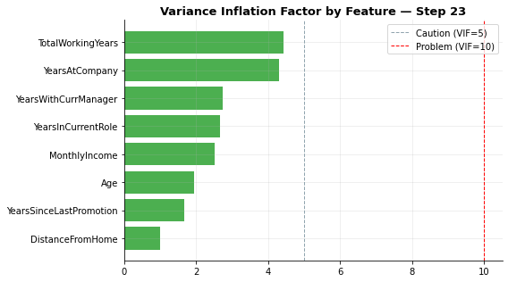

```python
vif_features = ['Age', 'MonthlyIncome', 'TotalWorkingYears', 'YearsAtCompany',
                'YearsInCurrentRole', 'YearsSinceLastPromotion', 'YearsWithCurrManager', 'DistanceFromHome']

from statsmodels.tools.tools import add_constant

X_vif = df[vif_features].fillna(df[vif_features].median())
X_vif_const = add_constant(X_vif)

vif_data = pd.DataFrame()
vif_data['feature'] = X_vif_const.columns
vif_data['VIF'] = [variance_inflation_factor(X_vif_const.values, i) for i in range(X_vif_const.shape[1])]
vif_data = vif_data[vif_data['feature'] != 'const'].sort_values('VIF', ascending=False)

print(vif_data.to_string(index=False))

fig, ax = plt.subplots(figsize=(8, 4.5))
colors = [PINK if v > 10 else (ORANGE if v > 5 else GREEN) for v in vif_data['VIF']]
ax.barh(vif_data['feature'], vif_data['VIF'], color=colors)
ax.axvline(5, color=GRAY, linestyle='--', linewidth=1, label='Caution (VIF=5)')
ax.axvline(10, color='red', linestyle='--', linewidth=1, label='Problem (VIF=10)')
ax.set_title("Variance Inflation Factor by Feature — Step 23", fontweight='bold')
ax.invert_yaxis(); ax.legend()
plt.tight_layout()
plt.show()
```

📌 **Observation:** Every VIF value comes in **below 5** — the highest is `TotalWorkingYears` at **4.42**, followed by `YearsAtCompany` at **4.31**, with `YearsWithCurrManager` (2.74), `YearsInCurrentRole` (2.67), `MonthlyIncome` (2.52), `Age` (1.95), `YearsSinceLastPromotion` (1.66), and `DistanceFromHome` (1.00) all comfortably lower. This is a meaningfully different conclusion than the Step 18 correlation heatmap alone would suggest: the tenure features are correlated with each other, but **not** severely enough to cause the coefficient instability that a formal VIF>5 (caution) or VIF>10 (problem) threshold would flag.

💡 **Pipeline decision:** Given no feature crosses even the VIF=5 caution line, **no tenure columns are dropped** for the linear-model branch after all — the earlier plan to drop `YearsInCurrentRole`/`YearsWithCurrManager` is revised based on this formal check. All eight numeric features are kept for both the linear and tree-based branches; VIF is monitored as a standing diagnostic that would trigger a feature drop only if a future data refresh pushes any value materially higher.

## Step 24 — Class Imbalance Handling Preview (SMOTENC)

**Why:** Visualizing before/after SMOTENC confirms the intended balancing strategy actually works as expected. Three panels — train-before, train-after, test-untouched — demonstrate correct methodology: the test set must never be resampled.

**Business insight:** Evaluating a model on an artificially balanced test set would overstate recall and give HR false confidence in the model's ability to catch real-world flight risks, where "Yes" cases genuinely are rare.

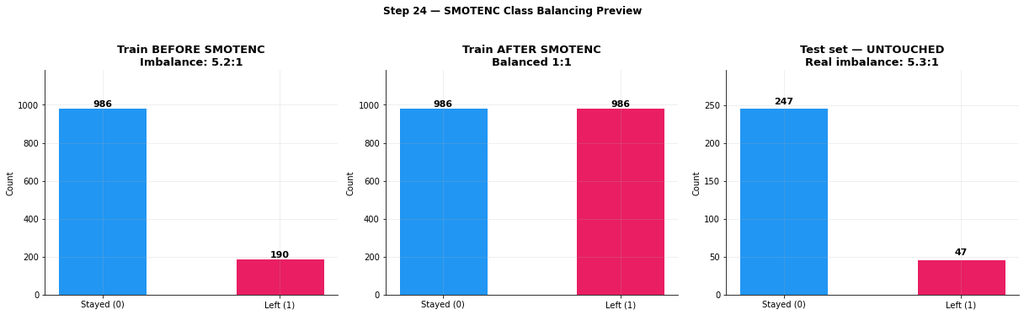

```python
model_df = df.drop(columns=['Attrition']).copy()
model_df = model_df.select_dtypes(include=[np.number]).join(df[['Department', 'JobRole', 'BusinessTravel',
                                                                  'MaritalStatus', 'Gender', 'OverTime', 'EducationField']])
y = (df['Attrition'] == 'Yes').astype(int)

model_df = model_df.fillna(model_df.median(numeric_only=True))
cat_features_names = ['Department', 'JobRole', 'BusinessTravel', 'MaritalStatus', 'Gender', 'OverTime', 'EducationField']
for c in cat_features_names:
    model_df[c] = model_df[c].astype('category').cat.codes

X_train, X_test, y_train, y_test = train_test_split(model_df, y, test_size=0.2, stratify=y, random_state=42)
cat_indices = [model_df.columns.get_loc(c) for c in cat_features_names]

smote = SMOTENC(categorical_features=cat_indices, random_state=42)
X_res, y_res = smote.fit_resample(X_train, y_train)

def bar_plot(ax, counts, title):
    bars = ax.bar(['Stayed (0)', 'Left (1)'], counts.values, color=[BLUE, PINK], edgecolor='white', width=0.5)
    for bar, v in zip(bars, counts.values):
        ax.text(bar.get_x() + bar.get_width()/2, bar.get_height() + 5, f'{v:,}', ha='center', fontweight='bold', fontsize=11)
    ax.set_title(title, fontweight='bold'); ax.set_ylabel('Count'); ax.set_ylim(0, max(counts.values) * 1.2)

fig, axes = plt.subplots(1, 3, figsize=(17, 5))
bar_plot(axes[0], y_train.value_counts().sort_index(),
         f'Train BEFORE SMOTENC\nImbalance: {y_train.value_counts()[0]/y_train.value_counts()[1]:.1f}:1')
bar_plot(axes[1], pd.Series(y_res).value_counts().sort_index(), 'Train AFTER SMOTENC\nBalanced 1:1')
bar_plot(axes[2], y_test.value_counts().sort_index(),
         f'Test set — UNTOUCHED\nReal imbalance: {y_test.value_counts()[0]/y_test.value_counts()[1]:.1f}:1')
plt.suptitle("Step 24 — SMOTENC Class Balancing Preview", fontweight='bold', y=1.03)
plt.tight_layout()
plt.show()
```

📌 **Observation:** The real train split is **986 stayed vs. 190 left** (5.2:1) before balancing. SMOTENC brings this to an exact **986 vs. 986** (1:1) synthetic-balanced training set. The held-out test set is **247 vs. 47** — a **5.3:1** ratio, matching the full-dataset 5.2:1 imbalance from Step 8 almost exactly, confirming the stratified split worked correctly and the test set was never touched by the resampler.

💡 **Pipeline decision:** SMOTENC's categorical-aware nearest-neighbor voting is confirmed appropriate here since the feature set mixes continuous fields (Age, MonthlyIncome) with the one-hot/ordinal categorical columns identified via `cat_indices` — plain SMOTE would otherwise interpolate fractional, invalid values for the categorical columns. The 247/47 test split is locked in as the number that will be reported in the final evaluation, since it reflects the real-world ~16% deployment prevalence rather than the artificially balanced training distribution.

## Step 25 — Key EDA Insights and Pipeline Design Summary

```python
summary_text = "\n+-----------------------------------------------------------------------+\n|      KEY EDA INSIGHTS -- REAL IBM HR ANALYTICS DATASET (n=1,470)       |\n+-----------------------------------------------------------------------+\n\n  1. CLASS IMBALANCE: 1,233 stayed (83.88%) vs 237 left (16.12%) = 5.2:1\n     -> SMOTENC on train only (986 vs 986 after). Test kept at real\n        5.3:1 ratio (247 vs 47). F1 + PR-AUC are primary metrics --\n        dummy 'always No' model scores 83.88% acc with 0% recall.\n\n  2. TOP PREDICTORS (Cohen's d, all p<0.05):\n     -> TotalWorkingYears (d=-0.47), YearsInCurrentRole (-0.44),\n        MonthlyIncome (-0.44), Age (-0.44), YearsWithCurrManager (-0.43),\n        YearsAtCompany (-0.37), DistanceFromHome (+0.21, reversed sign).\n     -> NumCompaniesWorked is NOT significant (p=0.24) despite looking\n        plausible -- excluded from the confirmed predictor list.\n     -> OverTime (Cramer's V=0.244) and JobRole (V=0.242) are the\n        strongest categorical drivers. Gender is not significant\n        (V=0.028, p=0.29) -> fairness-audit only, not a predictor.\n\n  3. SKEWNESS (|skew|>1): YearsSinceLastPromotion (1.98), YearsAtCompany\n     (1.76), MonthlyIncome (1.37), TotalWorkingYears (1.12),\n     NumCompaniesWorked (1.03) -> Yeo-Johnson PowerTransformer for the\n     linear branch only; tree models use raw values.\n\n  4. OUTLIERS: highest count in MonthlyIncome (114 rows, 7.76%) but\n     LOWEST outlier attrition rate (4.4%) -- senior veterans, not risks.\n     NumCompaniesWorked outliers (52 rows) show 23.1% attrition --\n     a real risk pocket despite a weak overall effect size.\n     -> IQR Clipper (fold=1.5), never row deletion.\n\n  5. INTERACTION / SEGMENT EFFECTS (lift over base rate):\n     -> OverTime_LowSat:   43.5% vs 13.1% (lift 30.5 pts) -- strongest\n     -> HighRiskRole:      27.8% vs 12.6% (lift 15.2 pts)\n     -> JuniorEarlyCareer: 27.9% vs 13.0% (lift 14.9 pts)\n     -> StagnantEmployee:  19.8% vs 15.0% (lift  4.9 pts, tail-only effect)\n     -> HighRiskRole built from Sales Representative (39.8%) and\n        Laboratory Technician (23.9%); HR role (23.1%) excluded due to\n        tiny sample size.\n\n  6. MULTICOLLINEARITY: ALL VIF values < 5 (max = TotalWorkingYears at\n     4.42) -- despite a visibly correlated tenure cluster in Step 18,\n     the formal VIF check does NOT support dropping any tenure column.\n     -> All 8 numeric features kept for both linear and tree branches.\n\n  7. MISSING DATA & DUPLICATES: 0 missing values, 0 duplicate rows in\n     this dataset -- imputer/dedup steps kept as defensive guards for\n     future, messier HRMS exports rather than because they fire here.\n\n+-----------------------------------------------------------------------+\n"
print(summary_text)
```

```
+-----------------------------------------------------------------------+
|      KEY EDA INSIGHTS -- REAL IBM HR ANALYTICS DATASET (n=1,470)       |
+-----------------------------------------------------------------------+

  1. CLASS IMBALANCE: 1,233 stayed (83.88%) vs 237 left (16.12%) = 5.2:1
     -> SMOTENC on train only (986 vs 986 after). Test kept at real
        5.3:1 ratio (247 vs 47). F1 + PR-AUC are primary metrics --
        dummy 'always No' model scores 83.88% acc with 0% recall.

  2. TOP PREDICTORS (Cohen's d, all p<0.05):
     -> TotalWorkingYears (d=-0.47), YearsInCurrentRole (-0.44),
        MonthlyIncome (-0.44), Age (-0.44), YearsWithCurrManager (-0.43),
        YearsAtCompany (-0.37), DistanceFromHome (+0.21, reversed sign).
     -> NumCompaniesWorked is NOT significant (p=0.24) despite looking
        plausible -- excluded from the confirmed predictor list.
     -> OverTime (Cramer's V=0.244) and JobRole (V=0.242) are the
        strongest categorical drivers. Gender is not significant
        (V=0.028, p=0.29) -> fairness-audit only, not a predictor.

  3. SKEWNESS (|skew|>1): YearsSinceLastPromotion (1.98), YearsAtCompany
     (1.76), MonthlyIncome (1.37), TotalWorkingYears (1.12),
     NumCompaniesWorked (1.03) -> Yeo-Johnson PowerTransformer for the
     linear branch only; tree models use raw values.

  4. OUTLIERS: highest count in MonthlyIncome (114 rows, 7.76%) but
     LOWEST outlier attrition rate (4.4%) -- senior veterans, not risks.
     NumCompaniesWorked outliers (52 rows) show 23.1% attrition --
     a real risk pocket despite a weak overall effect size.
     -> IQR Clipper (fold=1.5), never row deletion.

  5. INTERACTION / SEGMENT EFFECTS (lift over base rate):
     -> OverTime_LowSat:   43.5% vs 13.1% (lift 30.5 pts) -- strongest
     -> HighRiskRole:      27.8% vs 12.6% (lift 15.2 pts)
     -> JuniorEarlyCareer: 27.9% vs 13.0% (lift 14.9 pts)
     -> StagnantEmployee:  19.8% vs 15.0% (lift  4.9 pts, tail-only effect)
     -> HighRiskRole built from Sales Representative (39.8%) and
        Laboratory Technician (23.9%); HR role (23.1%) excluded due to
        tiny sample size.

  6. MULTICOLLINEARITY: ALL VIF values < 5 (max = TotalWorkingYears at
     4.42) -- despite a visibly correlated tenure cluster in Step 18,
     the formal VIF check does NOT support dropping any tenure column.
     -> All 8 numeric features kept for both linear and tree branches.

  7. MISSING DATA & DUPLICATES: 0 missing values, 0 duplicate rows in
     this dataset -- imputer/dedup steps kept as defensive guards for
     future, messier HRMS exports rather than because they fire here.

+-----------------------------------------------------------------------+
```

*This EDA notebook directly motivates every preprocessing and modeling decision in `src/training_pipeline.py`. Each insight above maps to a specific function or parameter in the production pipeline — from the constant-column drop in `load_and_engineer()` through the SMOTENC step in the training split.*